# Data Simulation Survival Analysis

Diego Vallarino

2023-05-08

# 1 Introduction

This analysis makes a comparison of different machine learning models for the survival analysis (time to event). For this, a simulated data set is used using the coxed library.

A df of 2000 observations has been generated, with 10 variables, considering 30% of censored data. The analysis is presented below.

# 2 Data Management

```
##           X1          X2         X3         X4          X5         X6
## 1  0.2639428  0.14568482  0.2373226  0.2646632 -0.33694195  0.5154498
## 2  0.2894704 -0.01326946 -0.2585683  0.2193539  0.65172970 -0.2702795
## 3 -0.1092926 -1.22313951  0.7390463  0.3004931  0.46978710  0.8003422
## 4  1.1876540 -0.03110633  0.4445615  0.9807541  0.83778885 -0.2273781
## 5 -0.3757817  0.72731220  0.2665582 -0.4347987  0.04442928  0.4539475
## 6 -0.8895765 -0.33019364 -0.2023037  0.4334723  0.25875652 -0.1280565
##            X7          X8         X9         X10 time status
## 1  0.09297309 -0.32446283 -0.7432473 -0.42703666   38      1
## 2  0.33867520 -0.66771654  0.3875719 -0.12484156   38      0
## 3  0.46970618 -0.70590294  1.2880690  0.07751145  250      1
## 4  0.90231299 -1.08097192  0.3052517 -1.34142525   74      0
## 5  0.57094569  0.25637998  0.1107153 -0.12439322  245      1
## 6 -0.32622357  0.04719174  0.3111969  0.31171002   36      1
```

# 3 Descriptive Analysis

The descriptive analysis involves analyzing each of the two dfs, the data.train and the data.test, since it will help us to understand if they are similar (on average).

```r
summary(data.train)
```

```
##        X1                  X2                  X3
##  Min.   :-1.643259   Min.   :-1.768287   Min.   :-1.666603
##  1st Qu.:-0.328724   1st Qu.:-0.345269   1st Qu.:-0.328609
##  Median :-0.009950   Median : 0.005304   Median :-0.017643
##  Mean   : 0.004678   Mean   : 0.009368   Mean   : 0.005106
##  3rd Qu.: 0.333655   3rd Qu.: 0.341717   3rd Qu.: 0.338669
##  Max.   : 1.729396   Max.   : 1.778555   Max.   : 1.524462
##        X4                  X5                   X6
##  Min.   :-1.532564   Min.   :-1.6626357   Min.   :-1.634405
##  1st Qu.:-0.327727   1st Qu.:-0.3537493   1st Qu.:-0.337343
##  Median : 0.023913   Median :-0.0000515   Median : 0.010571
##  Mean   : 0.007001   Mean   :-0.0077262   Mean   : 0.002326
##  3rd Qu.: 0.353590   3rd Qu.: 0.3361498   3rd Qu.: 0.337418
##  Max.   : 1.554504   Max.   : 1.4124091   Max.   : 1.631601
##        X7                  X8                  X9                X10
##  Min.   :-1.573962   Min.   :-1.521612   Min.   :-1.77783   Min.   :-1.368344
##  1st Qu.:-0.341656   1st Qu.:-0.347805   1st Qu.:-0.30345   1st Qu.:-0.339258
##  Median :-0.001712   Median :-0.013335   Median : 0.02207   Median : 0.010688
##  Mean   :-0.006196   Mean   :-0.006956   Mean   : 0.02393   Mean   : 0.002582
##  3rd Qu.: 0.319060   3rd Qu.: 0.316176   3rd Qu.: 0.34094   3rd Qu.: 0.330771
##  Max.   : 1.780742   Max.   : 1.575034   Max.   : 1.80514   Max.   : 1.873693
##       time           status
##  Min.   : 22.0   Min.   :0.0
##  1st Qu.: 38.0   1st Qu.:0.0
##  Median : 74.0   Median :1.0
##  Mean   :113.7   Mean   :0.7
##  3rd Qu.:183.0   3rd Qu.:1.0
##  Max.   :250.0   Max.   :1.0
```

```r
summary(data.test)
```

```
##        X1                  X2                 X3                 X4
##  Min.   :-1.450712   Min.   :-1.45253   Min.   :-1.44117   Min.   :-1.53256
##  1st Qu.:-0.352886   1st Qu.:-0.33938   1st Qu.:-0.32388   1st Qu.:-0.31516
##  Median : 0.001374   Median : 0.01639   Median : 0.01059   Median : 0.02503
##  Mean   :-0.009620   Mean   : 0.01210   Mean   : 0.02173   Mean   : 0.01976
##  3rd Qu.: 0.312144   3rd Qu.: 0.32719   3rd Qu.: 0.37318   3rd Qu.: 0.40977
##  Max.   : 1.729396   Max.   : 1.49693   Max.   : 1.37210   Max.   : 1.46894
##        X5                 X6                 X7                 X8
##  Min.   :-1.39917   Min.   :-1.34690   Min.   :-1.53538   Min.   :-1.521612
##  1st Qu.:-0.35386   1st Qu.:-0.29868   1st Qu.:-0.36264   1st Qu.:-0.347985
##  Median :-0.03212   Median : 0.01625   Median :-0.03048   Median :-0.009862
##  Mean   :-0.01160   Mean   : 0.01380   Mean   :-0.03964   Mean   :-0.001199
##  3rd Qu.: 0.33374   3rd Qu.: 0.33762   3rd Qu.: 0.29836   3rd Qu.: 0.301120
##  Max.   : 1.38647   Max.   : 1.63160   Max.   : 1.23872   Max.   : 1.575034
##        X9                X10                time           status
##  Min.   :-1.34735   Min.   :-1.57462   Min.   :  5.0   Min.   :0.0000
##  1st Qu.:-0.27540   1st Qu.:-0.32615   1st Qu.: 38.0   1st Qu.:0.0000
##  Median : 0.03657   Median : 0.02221   Median : 74.0   Median :1.0000
##  Mean   : 0.03215   Mean   : 0.02028   Mean   :113.4   Mean   :0.6667
##  3rd Qu.: 0.35466   3rd Qu.: 0.33711   3rd Qu.:180.2   3rd Qu.:1.0000
##  Max.   : 1.77392   Max.   : 1.87369   Max.   :250.0   Max.   :1.0000
```

# 4 Importance of Variables (SHAP)

```
## 6 x 11 sparse Matrix of class "dgCMatrix"
##
## 1 -0.06678626 -0.3322215  0.92546629 -0.2919065  0.1315697  0.002305435
## 2  0.36730009  0.4725030  0.33839881 -0.4515321 -0.4055315 -0.483953347
## 3  0.98754511  0.4017609  0.08713056 -1.1138542 -0.4735605  0.068259664
## 4  0.30466419  0.3092934 -0.09507955  0.3614162 -0.2937288  0.288013826
## 5 -0.90949371  0.4569764 -0.31476304 -0.1523511 -0.2287274  0.443773439
## 6 -0.01846339 -0.5595969  0.25104527  0.2605425 -0.7361789  0.759271103
##
## 1  0.3973971 -0.02024407 -0.33299277  0.5191094  73
## 2 -0.3612733  0.07304718 -0.02592171  0.2215797  36
## 3 -0.0660906  0.51466015 -0.06325097 -0.4070760 250
## 4  0.5005818  0.84303886  1.80513818  0.1292749  64
## 5  0.2268963 -0.04117929 -0.07414257  0.3717527  74
## 6  0.6811832  0.25907232  1.14728090 -0.3542836  36
```

```
##    Feature      Gain      Cover  Frequency
## 1:      X7 0.1432471 0.14409583 0.12698413
## 2:      X3 0.1281145 0.08901403 0.10317460
## 3:     X10 0.1150740 0.14697417 0.11111111
## 4:      X9 0.1077206 0.03201931 0.07936508
## 5:      X2 0.1069224 0.05143470 0.11111111
## 6:      X6 0.1007674 0.14189684 0.11111111
```

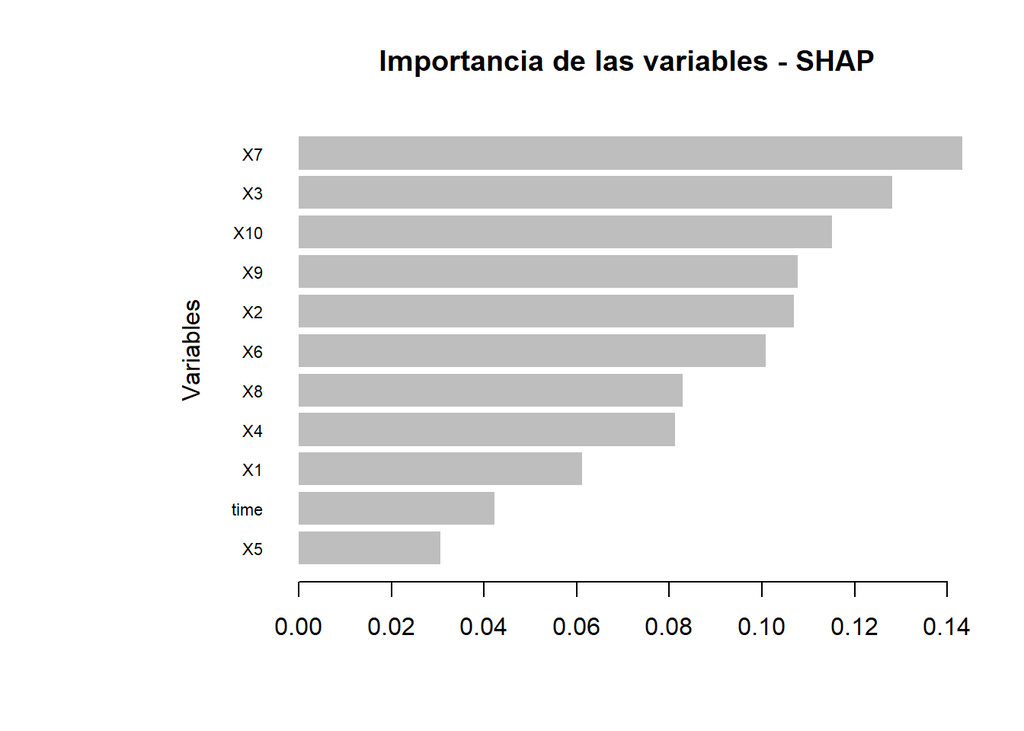

# 5 Traditional Models

## 5.1 Kaplan-Meier Model - non parametric survival model

```
## Call: survfit(formula = Surv(time, status) ~ 1, data = data.train)
##
##         n events median 0.95LCL 0.95UCL
## [1,] 1400    980    128      75     145
```

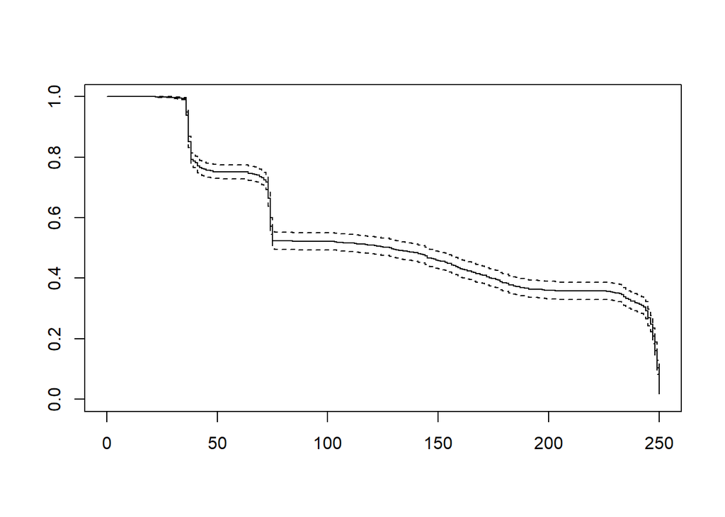

```
## Call: survfit(formula = Surv(time, status) ~ 1, data = data.train)
##
##  time n.risk n.event survival std.err lower 95% CI upper 95% CI
##    20   1400       0   1.0000 0.00000       1.0000       1.0000
##    50    930     330   0.7523 0.01188       0.7294       0.7759
##   100    541     266   0.5212 0.01443       0.4936       0.5502
##   250     46     384   0.0224 0.00674       0.0124       0.0404
```

## 5.2 Cox models - semi parametric survival model

```
##
##  Shapiro-Wilk normality test
##
## data:  fit4$residuals
## W = 0.8955, p-value < 2.2e-16
```

```
## Analysis of Deviance Table
##  Cox model: response is Surv(time, status)
## Terms added sequentially (first to last)
##
##       loglik  Chisq Df Pr(>|Chi|)
## NULL -6141.7
## X1   -6140.6 2.1232  1   0.145081
## X2   -6140.4 0.4981  1   0.480330
## X3   -6139.7 1.3197  1   0.250653
## X4   -6139.5 0.3384  1   0.560735
## X5   -6139.1 0.9588  1   0.327497
## X6   -6138.8 0.4662  1   0.494738
## X7   -6138.5 0.7162  1   0.397383
## X8   -6138.1 0.6591  1   0.416877
## X9   -6133.7 8.8290  1   0.002965 **
## X10  -6133.7 0.1196  1   0.729482
## ---
## Signif. codes:  0 '***' 0.001 '**' 0.01 '*' 0.05 '.' 0.1 ' ' 1
```

```
## Call:
## coxph(formula = Surv(time, status) ~ ., data = data.train, x = TRUE)
##
##   n= 1400, number of events= 980
##
##         coef exp(coef) se(coef)      z Pr(>|z|)
## X1   0.09990   1.10506  0.06407  1.559   0.1189
## X2   0.04956   1.05081  0.06554  0.756   0.4495
## X3  -0.07835   0.92464  0.06708 -1.168   0.2428
## X4  -0.02448   0.97582  0.06355 -0.385   0.7001
## X5  -0.06074   0.94107  0.06480 -0.937   0.3486
## X6  -0.04431   0.95665  0.06680 -0.663   0.5071
## X7  -0.05779   0.94385  0.06549 -0.882   0.3776
## X8   0.05493   1.05646  0.06391  0.859   0.3901
## X9  -0.19377   0.82384  0.06507 -2.978   0.0029 **
## X10  0.02274   1.02300  0.06575  0.346   0.7294
## ---
## Signif. codes:  0 '***' 0.001 '**' 0.01 '*' 0.05 '.' 0.1 ' ' 1
##
##     exp(coef) exp(-coef) lower .95 upper .95
## X1     1.1051     0.9049    0.9747    1.2529
## X2     1.0508     0.9516    0.9241    1.1949
## X3     0.9246     1.0815    0.8107    1.0546
## X4     0.9758     1.0248    0.8615    1.1053
## X5     0.9411     1.0626    0.8288    1.0685
## X6     0.9567     1.0453    0.8393    1.0905
## X7     0.9439     1.0595    0.8302    1.0731
## X8     1.0565     0.9466    0.9321    1.1974
## X9     0.8238     1.2138    0.7252    0.9359
## X10    1.0230     0.9775    0.8993    1.1637
##
## Concordance= 0.538  (se = 0.011 )
## Likelihood ratio test= 16.03  on 10 df,   p=0.1
## Wald test            = 15.95  on 10 df,   p=0.1
## Score (logrank) test = 15.95  on 10 df,   p=0.1
```

```
## Call: survfit(formula = fit4)
##
##  time n.risk n.event survival std.err lower 95% CI upper 95% CI
##    20   1400       0   1.0000 0.00000       1.0000       1.0000
##    50    930     330   0.7538 0.01185       0.7309       0.7774
##   150    460     330   0.4584 0.01473       0.4305       0.4882
##   200    328      94   0.3590 0.01469       0.3314       0.3890
##   250     46     226   0.0231 0.00672       0.0131       0.0409
```

# 6 Machine Learning Models

## 6.1 MTLR Model - machine learning model

```
##
## Call:  mtlr(formula = Surv(time, status) ~ ., data = data.train, nintervals = 9)
##
## Time points:
## [1]  37  38  70  73  74 129 172 244 248
##
##
## Weights:
##           Bias        X1       X2       X3        X4       X5        X6
## 37     -0.6901 -0.000281 -0.00150  0.00261  0.000831 -0.01105 -0.000113
## 38     -0.1022 -0.006287  0.00725 -0.00900  0.007698 -0.00681  0.001498
## 70      1.7399  0.010303  0.00662 -0.01916  0.006242 -0.00797 -0.002002
## 73     -0.9328  0.013759  0.00572 -0.01713  0.001962 -0.01460 -0.001280
## 74     -1.2198  0.017125  0.00532 -0.00458  0.001052 -0.01535 -0.011178
## 129.27  0.6689 -0.003144  0.00446 -0.01536  0.000952 -0.01124 -0.006294
## 172    -0.1434  0.006695  0.00433 -0.00585 -0.000791 -0.00157 -0.012484
## 244     0.0232  0.004554  0.00433 -0.00723  0.000772  0.00768 -0.008142
## 248    -0.5980  0.009992  0.00438 -0.00654 -0.006423 -0.00487  0.002527
##              X7        X8       X9      X10
## 37      0.00146 -0.002561  0.00561 -0.01233
## 38     -0.00799 -0.003744 -0.00568  0.00383
## 70      0.00174  0.005475  0.00141 -0.00600
## 73     -0.00175  0.005976 -0.00201 -0.00936
## 74     -0.00250  0.000757 -0.01959 -0.01410
## 129.27 -0.00264  0.003983 -0.02131 -0.01081
## 172    -0.01179  0.010518 -0.01597  0.00505
## 244    -0.00889  0.009205 -0.01647  0.00794
## 248    -0.00207  0.008491 -0.01635  0.01250
```

## 6.2 Random Forest

```
## [1] 0.4788653
```

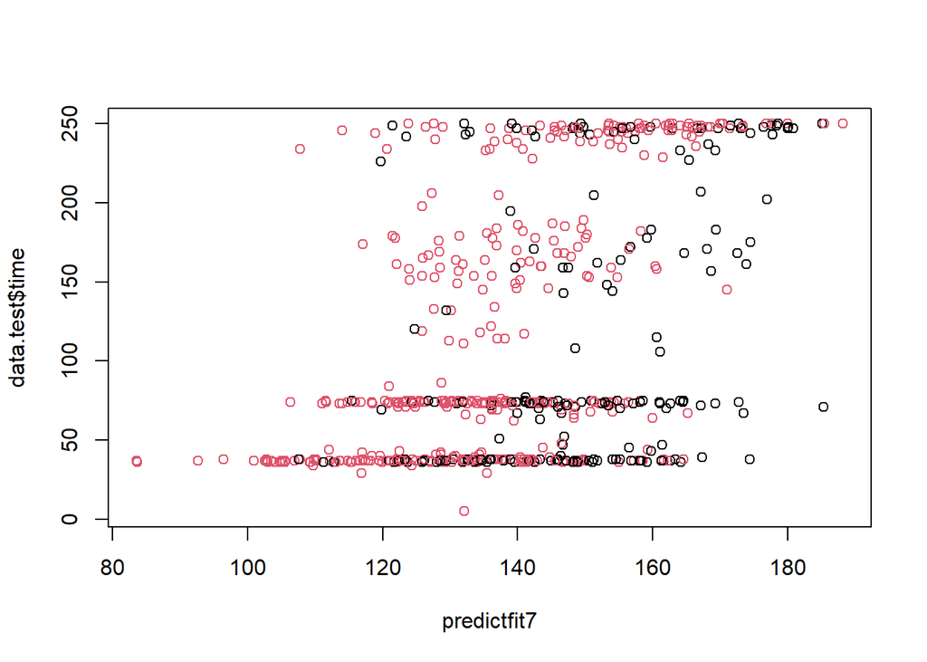

```
##                          Sample size: 1400
##                     Number of deaths: 980
##                      Number of trees: 500
##            Forest terminal node size: 15
##        Average no. of terminal nodes: 74.394
## No. of variables tried at each split: 4
##               Total no. of variables: 10
##        Resampling used to grow trees: swor
##     Resample size used to grow trees: 885
##                             Analysis: RSF
##                               Family: surv
##                       Splitting rule: logrank *random*
##        Number of random split points: 10
##                           (OOB) CRPS: 0.1984431
##    (OOB) Requested performance error: 0.50490003
```

## 6.3 DeepSurv Model

```
##
##  DeepSurv Neural Network
##
## Call:
##   deepsurv(data = data.train, frac = 0.5, activation = "relu",      num_nodes = c(4L, 8L, 4L, 2L), dropout = 0.3, early_stopping = TRUE,      batch_size = 32L, epochs = 100L)
##
## Response:
##   Surv(time, status)
## Features:
##   {X1, X2, X3, X4, X5, X6, X7, X8, X9, X10}
```

# 7 Survival Kernel SVM

```
##
## survivalsvm result
##
## Call:
##
##  survivalsvm(Surv(time, status) ~ ., data = data.train, type = "regression", gamma.mu = 1, opt.meth = "quadprog", kernel = "lin_kernel")
##
## Survival svm approach              : regression
## Type of Kernel                     : lin_kernel
## Optimization solver used           : quadprog
## Number of support vectors retained : 1281
## survivalsvm version                : 0.0.5
```

# 8 Models Ranking List

```
## [[1]]
##     Cindex      Model
## 1 0.535093        Cox
## 2 0.523530       MTLR
## 3 0.748021 RandForest
## 4 0.902952   DeepSurv
## 5 0.519238  KernelSVM
```

# 9 Models Ranking Chart

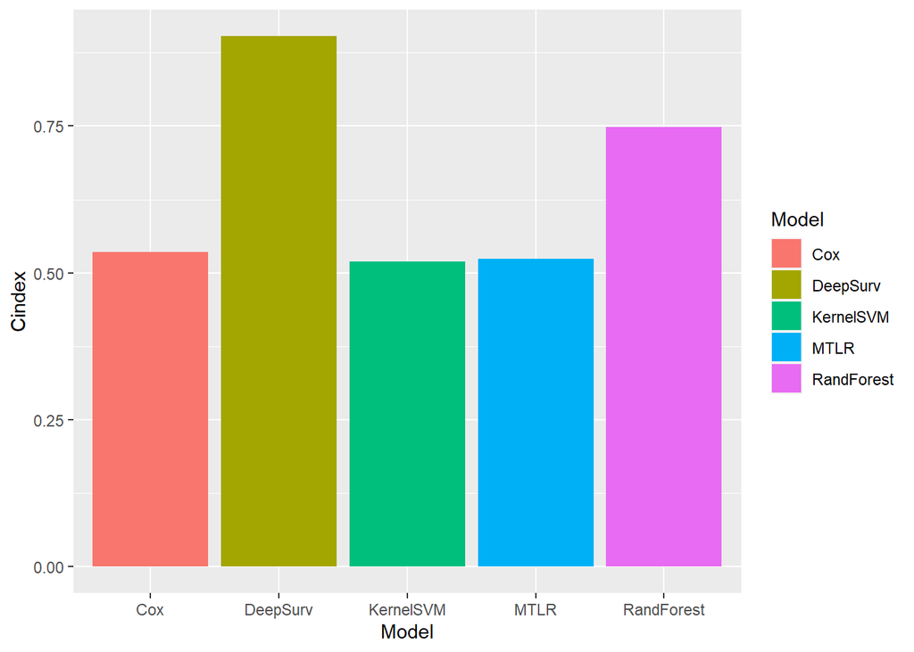

# 10 Conclusion

**Why DeepSurv outperforms than Random Forest, KernelSVM and MTLR?**

DeepSurv is a deep learning framework designed for survival analysis, which has been shown to outperform other traditional machine learning methods such as Random Forest, Kernel SVM, and MTLR (Multi-Task Logistic Regression) in many cases.

The reason for DeepSurv’s superior performance lies in its ability to capture complex nonlinear relationships between input features and survival outcomes. In contrast, traditional methods like Random Forest, Kernel SVM, and MTLR typically assume a linear or low-dimensional relationship between features and outcomes, which can be limiting in complex datasets.

Furthermore, DeepSurv is specifically designed for survival analysis, which means it can handle censored data (i.e., instances where survival time is unknown), whereas some of the traditional machine learning methods may not handle this data effectively.

In summary, DeepSurv’s ability to capture complex relationships and handle censored data makes it a superior choice for survival analysis compared to traditional machine learning methods like Random Forest, Kernel SVM, and MTLR, which may struggle in more complex datasets.